# Practical Machine Learning

This is my solution for the Coursera Practical Machine Learning course project.

## I. Data Cleanup

The are lots of missing values, as well as invalid values such as “#DIV/0!” that need to be cleaned up. We need to make sure that all invalid entries are read as NA so that they can be handled. Hence, I chose to read in the input file as follows:

```r
pml.train <- read.csv("pml-training.csv",na.strings = c("",",","#DIV/0!","NA"),stringsAsFactors=FALSE)
```

We can check the distribution of classes. Class imbalance can cause many issues during the training of Machine Learning algorithms.

```r
table(pml.train$classe)
```

```
##
##    A    B    C    D    E
## 5580 3797 3422 3216 3607
```

We see that class A is a bit over-represented, but not to a huge extent.

Also, we need to handle missing data. The plot of the number of NA values per column:

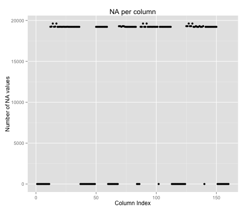

As we can see, lots of columns have a very high number of missing values. If there were only a few missing values, then the missing values could be imputed. However, in this case I chose to drop columns with missing values.

```r
complete_cols_names <- names(pml.train)[pml.train.na.count == 0]
df2 <- pml.train[,complete_cols_names]
df2[,"classe"] <- as.factor(df2[,"classe"])
```

The final cleaned data frame has the following columns:

```r
names(df2)
```

```
##  [1] "X"                    "user_name"            "raw_timestamp_part_1"
##  [4] "raw_timestamp_part_2" "cvtd_timestamp"       "new_window"
##  [7] "num_window"           "roll_belt"            "pitch_belt"
## [10] "yaw_belt"             "total_accel_belt"     "gyros_belt_x"
## [13] "gyros_belt_y"         "gyros_belt_z"         "accel_belt_x"
## [16] "accel_belt_y"         "accel_belt_z"         "magnet_belt_x"
## [19] "magnet_belt_y"        "magnet_belt_z"        "roll_arm"
## [22] "pitch_arm"            "yaw_arm"              "total_accel_arm"
## [25] "gyros_arm_x"          "gyros_arm_y"          "gyros_arm_z"
## [28] "accel_arm_x"          "accel_arm_y"          "accel_arm_z"
## [31] "magnet_arm_x"         "magnet_arm_y"         "magnet_arm_z"
## [34] "roll_dumbbell"        "pitch_dumbbell"       "yaw_dumbbell"
## [37] "total_accel_dumbbell" "gyros_dumbbell_x"     "gyros_dumbbell_y"
## [40] "gyros_dumbbell_z"     "accel_dumbbell_x"     "accel_dumbbell_y"
## [43] "accel_dumbbell_z"     "magnet_dumbbell_x"    "magnet_dumbbell_y"
## [46] "magnet_dumbbell_z"    "roll_forearm"         "pitch_forearm"
## [49] "yaw_forearm"          "total_accel_forearm"  "gyros_forearm_x"
## [52] "gyros_forearm_y"      "gyros_forearm_z"      "accel_forearm_x"
## [55] "accel_forearm_y"      "accel_forearm_z"      "magnet_forearm_x"
## [58] "magnet_forearm_y"     "magnet_forearm_z"     "classe"
```

## II. Feature Visualization and Selection

The first seven columns do not contain actual physical measurements, and should be considered as meta-data. Hence, these columns will not be used as features:

```r
names(df2)[1:7]
```

```
## [1] "X"                    "user_name"            "raw_timestamp_part_1"
## [4] "raw_timestamp_part_2" "cvtd_timestamp"       "new_window"
## [7] "num_window"
```

This leaves us with 53 columns, of which column 60 is the predictor variable. Hence, there are 52 features to train on.

Not all these 52 features might be useful. We can try to analyze if there are any redundant features.

a. Near Zero Variance

Some features contain almost all identical values, resulting in 0 or close to 0 variance. Such features would not be useful and may be dropped:

```r
library(caret)
df2_training <- df2[,8:59] #omit classe, and first 7 features for visualization purposes.
nzv <- nearZeroVar(df2_training, saveMetrics=TRUE)
#Number of Features with Zero Variance:
sum(nzv$zeroVar == TRUE)
```

```
## [1] 0
```

```r
#Number of Features with Near Zero Variance:
sum(nzv$nzv == TRUE)
```

```
## [1] 0
```

There were no features with 0 or near 0 variance.

b. Collinearity

Some features are highly correlated, and this can cause problems with certain classifiers. We can visualize the degree of correlation as follows:

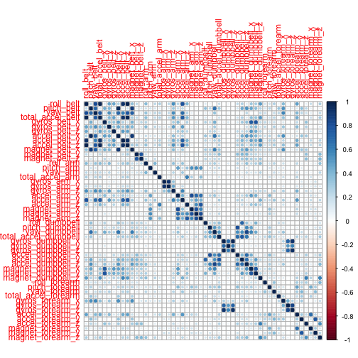

```r
library(corrplot)
#correlations
M <- abs(cor(df2_training))
corrplot(M, method="circle")
```

We can list the pairs of variables with correlation > 0.8:

```r
diag(M) <- 0
which(M > 0.8,arr.ind=T)
```

```
##                  row col
## yaw_belt           3   1
## total_accel_belt   4   1
## accel_belt_y       9   1
## accel_belt_z      10   1
## accel_belt_x       8   2
## magnet_belt_x     11   2
## roll_belt          1   3
## roll_belt          1   4
## accel_belt_y       9   4
## accel_belt_z      10   4
## pitch_belt         2   8
## magnet_belt_x     11   8
## roll_belt          1   9
## total_accel_belt   4   9
## accel_belt_z      10   9
## roll_belt          1  10
## total_accel_belt   4  10
## accel_belt_y       9  10
## pitch_belt         2  11
## accel_belt_x       8  11
## gyros_arm_y       19  18
## gyros_arm_x       18  19
## magnet_arm_x      24  21
## accel_arm_x       21  24
## magnet_arm_z      26  25
## magnet_arm_y      25  26
## accel_dumbbell_x  34  28
## accel_dumbbell_z  36  29
## gyros_dumbbell_z  33  31
## gyros_forearm_z   46  31
## gyros_dumbbell_x  31  33
## gyros_forearm_z   46  33
## pitch_dumbbell    28  34
## yaw_dumbbell      29  36
## gyros_forearm_z   46  45
## gyros_dumbbell_x  31  46
## gyros_dumbbell_z  33  46
## gyros_forearm_y   45  46
```

There are cleary a number of correlated variables. This can cause some problems with some training algorithms. It is something to keep in mind, but for now we will not try and do any further feature subsetting.

## III. Predictive Modelling

### Data Splitting:

We will split our given Training data into 2 new sets. The rationale is:

a. Training Set: Use Cross Validation on this set for model tuning and parameter selection. Cross validation will also provide an Out-of-Sample error estimate, aka an estimate of the Generalization error.

b. Testing Set: This is clean test set, not touched during training and validation. It will be used only for testing our models, and providing a second estimate of the Out-of-sample error.

Note: Since Cross-Validation is being used, if the data set was very small I would drop the Testing Set entirely, and rely on the Cross-Validation error estimates only.

```r
trainIndex <- createDataPartition(df2$classe, p = 0.75,list=FALSE)
trainX <- df2[trainIndex,8:59]
trainY <- df2[trainIndex,60]
testX <- df2[-trainIndex,8:59]
testY <- df2[-trainIndex,60]
```

### Model Selection:

We will try a number of predictive models, including Linear Discriminant Analysis (LDA), Support Vector Machines (SVM), Boosted Trees (GBM) and Random Forests (RF).

We will be using 5-fold cross validation:

```r
cvCtrl <- trainControl(method="cv",number=5,classProbs=TRUE)
```

### a. Linear Discriminant Analysis:

```r
model_lda <- train(x=trainX, y=trainY, method="lda",preProc=c("center","scale"),trControl=cvCtrl)
```

The summary of the LDA model:

```r
model_lda
```

```
## Linear Discriminant Analysis
##
## 14718 samples
##    52 predictor
##     5 classes: 'A', 'B', 'C', 'D', 'E'
##
## Pre-processing: centered, scaled
## Resampling: Cross-Validated (5 fold)
## Summary of sample sizes: 11773, 11774, 11775, 11774, 11776
## Resampling results
##
##   Accuracy   Kappa      Accuracy SD  Kappa SD
##   0.7040364  0.6254518  0.02019223   0.02552771
##
##
```

The LDA model had a quite poor Cross-Validaton error rate, only ~70% accuracy. We can double check this by looking at the prediction accuracy on the test set:

```r
model_lda_pred <- predict(model_lda, testX)
confusionMatrix(model_lda_pred, testY)
```

```
## Confusion Matrix and Statistics
##
##           Reference
## Prediction    A    B    C    D    E
##          A 1169  142   86   53   39
##          B   28  600   79   36  166
##          C  103  128  540  108   78
##          D   87   32  127  578   91
##          E    8   47   23   29  527
##
## Overall Statistics
##
##                Accuracy : 0.6962
##                  95% CI : (0.6831, 0.709)
##     No Information Rate : 0.2845
##     P-Value [Acc > NIR] : < 2.2e-16
##
##                   Kappa : 0.6151
##  Mcnemar's Test P-Value : < 2.2e-16
##
## Statistics by Class:
##
##                      Class: A Class: B Class: C Class: D Class: E
## Sensitivity            0.8380   0.6322   0.6316   0.7189   0.5849
## Specificity            0.9088   0.9219   0.8970   0.9178   0.9733
## Pos Pred Value         0.7851   0.6601   0.5643   0.6317   0.8312
## Neg Pred Value         0.9338   0.9126   0.9202   0.9433   0.9124
## Prevalence             0.2845   0.1935   0.1743   0.1639   0.1837
## Detection Rate         0.2384   0.1223   0.1101   0.1179   0.1075
## Detection Prevalence   0.3036   0.1854   0.1951   0.1866   0.1293
## Balanced Accuracy      0.8734   0.7771   0.7643   0.8184   0.7791
```

The accuracy is again only 69%.

The low accuracy might be due to some of the assumptions of the LDA model being violated. The features may not be jointly jointly gaussian. Another possibility is that the training set is not linearly separable. We could use an extension of LDA known as QDA (Quadratic Discriminant Analysis) that results in non-linear decision boundaries. However, lets move on to some more modern classifiers.

### b. Support Vector Machines (SVM)

Support Vector Machines are a form of Maximum Margin classifiers, that use some clever tricks such as Kernels to transform a given feature space into a higher dimensional space. Even if the training data set is not linearly separable in the original feature space, it can be separable in the higher dimensional space.

There is one main parameter that is used for tuning SVM models, known as the Cost parameter C. C can be adjusted to trade off Bias vs. Variance.

R's caret package automatically tunes the SVM model over a grid of possible C values during cross-validation, and chooses the C value that provides the lowest Cross-Validation error rate.

Set up an SVM with the Radial Basis Function as a Kernel:

```r
svmTune <- train(x=trainX, y=trainY, method="svmRadial",tuneLength=18,preProc=c("center","scale"),trControl=cvCtrl)
```

The details of the trained SVM model:

```r
svmTune
```

```
## Support Vector Machines with Radial Basis Function Kernel
```

```
## 14718 samples
##    52 predictor
##     5 classes: 'A', 'B', 'C', 'D', 'E'
##
## Pre-processing: centered, scaled
## Resampling: Cross-Validated (5 fold)
## Summary of sample sizes: 11775, 11774, 11775, 11773, 11775
## Resampling results across tuning parameters:
##
##   C         Accuracy   Kappa      Accuracy SD  Kappa SD
##       0.25  0.7767366  0.7151968  0.009914225  0.012716922
##       0.50  0.7960328  0.7401889  0.008165017  0.010421627
##       1.00  0.8071757  0.7546543  0.006449421  0.008167139
##       2.00  0.8149216  0.7647875  0.006136909  0.007742367
##       4.00  0.8160083  0.7662345  0.005920451  0.007450784
##       8.00  0.8273543  0.7806965  0.003958023  0.004990206
##      16.00  0.8356436  0.7911869  0.002811904  0.003496744
##      32.00  0.8400602  0.7967914  0.004315031  0.005411543
##      64.00  0.8374799  0.7934958  0.011388056  0.014425457
##     128.00  0.8418961  0.7991374  0.008664669  0.010989239
##     256.00  0.8448172  0.8028545  0.008081208  0.010256781
##     512.00  0.8438653  0.8016141  0.007975908  0.010107354
##    1024.00  0.8449522  0.8029877  0.007372973  0.009346725
##    2048.00  0.8431178  0.8006283  0.008865547  0.011303888
##    4096.00  0.8394487  0.7959391  0.008193576  0.010427875
##    8192.00  0.8423704  0.7996823  0.010433023  0.013319145
##   16384.00  0.8423705  0.7997144  0.014812764  0.018900090
##   32768.00  0.8428459  0.8002861  0.007155333  0.009114100
##
## Tuning parameter 'sigma' was held constant at a value of 0.01434579
## Accuracy was used to select the optimal model using  the largest value.
## The final values used for the model were sigma = 0.01434579 and C = 1024.
```

The Cross-Validation accuracy for the optimal parameter was ~ 84%. Better than LDA, but still not great. The optimal value for C during Cross-Validaton was 1024. We can visualize this, by plotting the CV accuracy vs. C:

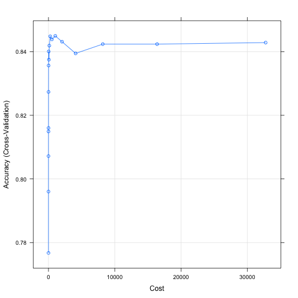

```r
plot(svmTune)
```

The prediction accuracy results for the SVM are:

```r
svm_pred <- predict(svmTune,testX)
confusionMatrix(svm_pred, testY)
```

```
## Confusion Matrix and Statistics
##
##           Reference
## Prediction    A    B    C    D    E
##          A 1391    3    5   81   33
##          B    3  923   39   32   81
##          C    0   23  759  104   90
##          D    0    0   52  366   51
##          E    1    0    0  221  646
##
## Overall Statistics
##
##                Accuracy : 0.833
##                  95% CI : (0.8223, 0.8433)
##     No Information Rate : 0.2845
##     P-Value [Acc > NIR] : < 2.2e-16
##
##                   Kappa : 0.7877
##  Mcnemar's Test P-Value : < 2.2e-16
##
## Statistics by Class:
##
##                      Class: A Class: B Class: C Class: D Class: E
## Sensitivity            0.9971   0.9726   0.8877  0.45522   0.7170
## Specificity            0.9652   0.9608   0.9464  0.97488   0.9445
## Pos Pred Value         0.9194   0.8562   0.7777  0.78038   0.7442
## Neg Pred Value         0.9988   0.9932   0.9756  0.90124   0.9368
## Prevalence             0.2845   0.1935   0.1743  0.16395   0.1837
## Detection Rate         0.2836   0.1882   0.1548  0.07463   0.1317
## Detection Prevalence   0.3085   0.2198   0.1990  0.09564   0.1770
## Balanced Accuracy      0.9812   0.9667   0.9171  0.71505   0.8308
```

The predicion accuracy was 83.3%, in line with the Cross-Validation accuracy estimates. We could probably improve the prediction accuracy with more feature engineering, such as improved scaling. We could also iterate over more tuning parameters, such as Gamma with is specific to the RBF Kernel.

### c. Gradient Boosting (GBM)

Gradient Boosting is a Classification tree based boosting algorithm. It produces an ensemble of simple Decision Tree classifiers using boosting, and produces a final classification based on these.

The main parameters to tune are:

n.trees: # Boosting Iterations; interaction.depth: Max Tree Depth for each of the weak learners; n.minobsinnode : Min. Terminal Node Size, useful for Bias/Variance trade-offs

We can train a GBM model as follows. Caret will automatically provide some tuning during Cross-Validation:

```r
model_gbm <- train(x=trainX, y=trainY,method="gbm",trControl=cvCtrl)
```

The details of the GBM model:

```r
model_gbm
```

```
## Stochastic Gradient Boosting
##
## 14718 samples
##    52 predictor
##     5 classes: 'A', 'B', 'C', 'D', 'E'
##
## No pre-processing
## Resampling: Cross-Validated (5 fold)
## Summary of sample sizes: 11774, 11775, 11775, 11774, 11774
## Resampling results across tuning parameters:
##
##   interaction.depth  n.trees  Accuracy   Kappa      Accuracy SD
##   1                   50      0.7530235  0.6869570  0.013432814
##   1                  100      0.8192699  0.7713042  0.010948979
##   1                  150      0.8558915  0.8177145  0.008632997
##   2                   50      0.8588806  0.8212209  0.005506786
##   2                  100      0.9066454  0.8818641  0.005507547
##   2                  150      0.9319878  0.9139407  0.006132994
##   3                   50      0.8981522  0.8710408  0.005241843
##   3                  100      0.9425190  0.9272612  0.005142353
##   3                  150      0.9616115  0.9514359  0.004894559
##   Kappa SD
##   0.017099047
##   0.013753575
##   0.010887172
##   0.006968057
##   0.006947669
##   0.007740928
##   0.006633072
##   0.006519127
##   0.006198906
##
## Tuning parameter 'shrinkage' was held constant at a value of 0.1
##
## Tuning parameter 'n.minobsinnode' was held constant at a value of 10
## Accuracy was used to select the optimal model using  the largest value.
## The final values used for the model were n.trees = 150,
##  interaction.depth = 3, shrinkage = 0.1 and n.minobsinnode = 10.
```

Choosing the number of iterations to be 150, and the interaction depth to be 3 produces the best CV accuracy, which is quite good, ~96 %.

We can visualize the interaction of the parameters on accuracy as follows:

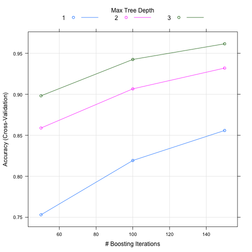

```r
plot(model_gbm)
```

As the number of iterations is increased, and the the interaction depth is increased, the CV accuracy keeps improving. From this it looks like we are underfitting, and increasing the model complexity should lead to even better accuracy estimates.

We can check the accuracy on our held out test set to make sure that the CV accuracy estimates are reliable:

```r
model_gbm_pred <- predict(model_gbm,testX)
confusionMatrix(model_gbm_pred, testY)
```

```
## Confusion Matrix and Statistics
##
##           Reference
## Prediction    A    B    C    D    E
##          A 1366   36    0    1    1
##          B   18  883   29    2   11
##          C    6   28  813   30    4
##          D    5    1   12  766   16
##          E    0    1    1    5  869
##
## Overall Statistics
##
##                Accuracy : 0.9578
##                  95% CI : (0.9518, 0.9632)
##     No Information Rate : 0.2845
##     P-Value [Acc > NIR] : < 2.2e-16
##
##                   Kappa : 0.9466
##  Mcnemar's Test P-Value : 1.971e-05
##
## Statistics by Class:
##
##                      Class: A Class: B Class: C Class: D Class: E
## Sensitivity            0.9792   0.9305   0.9509   0.9527   0.9645
## Specificity            0.9892   0.9848   0.9832   0.9917   0.9983
## Pos Pred Value         0.9729   0.9364   0.9228   0.9575   0.9920
## Neg Pred Value         0.9917   0.9833   0.9896   0.9907   0.9921
## Prevalence             0.2845   0.1935   0.1743   0.1639   0.1837
## Detection Rate         0.2785   0.1801   0.1658   0.1562   0.1772
## Detection Prevalence   0.2863   0.1923   0.1796   0.1631   0.1786
## Balanced Accuracy      0.9842   0.9576   0.9670   0.9722   0.9814
```

The test set accuracy is 95.7%, which is the best so far.

### d. Random Forests

The last model to test will be the Random Forest. Random Forests are similar to Bagging techniques, in that they use bootstrapping to create new training sets, and produce an ensemble of decision trees using these sets.

There is a random component, in that during the building of tree, at each split only a subset of features are selected. This produces a higher diversity in the ensemble of decision trees, and de-correlates them. This lowers the variance when the models as aggregated.

The mtry parameter controls the #Randomly Selected Predictors, and this will be tuned during the Cross Validation process.

We can train our Random Forest as follows:

```r
model_rf <- readRDS("trained_random_forest2.rds")
```

```r
model_rf <- train(x=trainX, y=trainY, method="rf",trControl=cvCtrl)
```

The results of the Cross-Validation:

```r
model_rf
```

```
## Random Forest
##
## 14718 samples
##    52 predictor
##     5 classes: 'A', 'B', 'C', 'D', 'E'
##
## No pre-processing
## Resampling: Cross-Validated (5 fold)
## Summary of sample sizes: 11774, 11774, 11774, 11776, 11774
## Resampling results across tuning parameters:
##
##   mtry  Accuracy   Kappa      Accuracy SD  Kappa SD
##    2    0.9912353  0.9889118  0.001881602  0.002380712
##   27    0.9912356  0.9889128  0.001769867  0.002238644
##   52    0.9845087  0.9804010  0.001240595  0.001573174
##
## Accuracy was used to select the optimal model using  the largest value.
## The final value used for the model was mtry = 27.
```

The optimal value of mtry is 27, out of the total number of predictors which is 52. The CV accuracy is very high, > 99%, easily the best so far.

We can verify the CV accuracy estimate using the test set:

```r
model_rf_pred <- predict(model_rf, testX)
confusionMatrix(model_rf_pred, testY)
```

```
## Confusion Matrix and Statistics
##
##           Reference
## Prediction    A    B    C    D    E
##          A 1394    6    0    0    0
##          B    1  941    5    0    0
##          C    0    1  844    8    1
##          D    0    1    6  796    8
##          E    0    0    0    0  892
##
## Overall Statistics
##
##                Accuracy : 0.9925
##                  95% CI : (0.9896, 0.9947)
##     No Information Rate : 0.2845
##     P-Value [Acc > NIR] : < 2.2e-16
##
##                   Kappa : 0.9905
##  Mcnemar's Test P-Value : NA
##
## Statistics by Class:
##
##                      Class: A Class: B Class: C Class: D Class: E
## Sensitivity            0.9993   0.9916   0.9871   0.9900   0.9900
## Specificity            0.9983   0.9985   0.9975   0.9963   1.0000
## Pos Pred Value         0.9957   0.9937   0.9883   0.9815   1.0000
## Neg Pred Value         0.9997   0.9980   0.9973   0.9980   0.9978
## Prevalence             0.2845   0.1935   0.1743   0.1639   0.1837
## Detection Rate         0.2843   0.1919   0.1721   0.1623   0.1819
## Detection Prevalence   0.2855   0.1931   0.1741   0.1654   0.1819
## Balanced Accuracy      0.9988   0.9950   0.9923   0.9932   0.9950
```

The test set accuracy estimate is also > 99 %.

## Conclusion

Out of the 4 models trained, LDA, SVM, GBM and RF, the Random Forest Model had the best test set accuracy, > 99 %.

The GBM model also had a quite high accuracy of > 95 %. By increasing the model complexity, this accuracy could be boosted further.

The SVM model had an accuracy of 83%. More in-depth feature engineering and paramter tuning will be required to boost its performance.

The LDA model had a quite low accuracy of 70%. The data is probably not linearly separable, or some of the model assumptions are violated.

The RF model was used to generate the predictions for the 20 test examples. It correctly classified all of them.